# Bad Neighbor Analysis Biogeographic Analysis Package

Enrique L. Montaño, PhD

Started: July-1-2018

```r
# libraries for the notebook
library(tidyverse)
source("R/generate_bn_count_map.R")
```

# Purpose

There are approximately 6000 distinct non-native species (plant and animal) currently documented in the Lower 48 United States (Simpson and Eyler 2018). Not every species is found or will be found in a given state. The purpose of this provisional bio-geographic analysis package is to create a state-by-state list of regulated non-native (i.e. invasive) species found in adjacent states, but not yet documented in the state of interest.

The bio-geographic analysis package uses the Biodiversity Information Serving Our Nation (BISON) species occurrence database https://bison.usgs.gov to determine species occurrences in the United States and its Territories. The data in BISON provide researchers with records of biological occurrence gathered across multiple agencies and organizations as a single, online resource.

This package was motivated by work undertaken for the [Western Governors Association](http://westgov.org), supporting their [Biosecurity and Invasive Species Initiative](http://westgov.org/initiatives/biosecurity-and-invasive-species-initiative). The original analysis was designed to answer the following questions:

1. What species occur in the Western States? These states are defined as states west of Minnesota (MN), Iowa (IA), Missouri ), Arkansas (AR), and Louisiana (LA).
2. What species occur in the states immediately adjacent to the Western States?
- Defined as: MN, IA, MO, AR, LA
3. What species from the Tier States (part 2) **DO NOT** occur in the Western States (part 1)?
4. Which result species from part 3 are non-native?

This original analysis was expanded and refined to individual states across the Lower 48 Unites States by applying a similar logic at a new scale to benefit a larger user group. Stakeholders like the Western Governor Association can use the “Bad Neighbor” analysis to see a list of species of concern to develop monitoring and management strategies before invasion. Results from the package can help state biologists, foresters, and rangeland managers in federal agencies like the Bureau of Land Management set species priorities for control treatments to benefit land conservation and promote healthy ecosystems.

The Bad Neighbor analysis can be run on any type of taxon for which the Biodiversity Information Serving Our Nation (BISON) species occurrence database has records. For the sake of illustration, a subset of taxonomic classes and families were selected to demonstrate the analysis. Those groups include species of high concern in the plant, animal and insect kingdoms. Groups chosen were:

1. Specific groups of plants:
   - Tree/Shrub
   - Grass
   - Ivy/Vines
   - Forb/Herb
2. Insects
3. Birds

## Informal Taxonomic Groups

Taxonomy does not accurately describe how an end user might approach grouping invasive species. For example, at the Class level, there are 56 entries describing the non-native species in [(Simpson and Eyler 2018). A more intuitive approach might be to group species into informal classifications like tree/shrub. The problem here is there is no one Family or Class that describes this sub-group; hence informal.

The [USDA PLANTS](https://www.plants.usda.gov/about_plants.html) database provides a habitat flag to describe the generalized growth habit of various species like tree, shrub, subshrub, or combinations thereof. Therefore, a list of taxonomic Families that incorporate tree/shrub can be developed from the PLANTS habitat.

A series of families related by habit have been formed and a bad neighbor analysis is run for each of these groups. Each of the informal groups listed below have an associated lookup table for the hierarchy homonym strings:

- data/forb_herb_hierarchy_strings.csv
- data/grasses_hierarchy_strings.csv
- data/ivy_vines_hierarchy_strings.csv
- data/tree_shrub_hierarchy_strings.csv

## Processing steps

The following outlines the various stages of running the Bad Neighbor BAP. The process is developed in three primary steps:

State list  
1) Query individual state for a list of all species at a given taxonomic group. The species group list can be generated from any valid taxonomic group;

Buffer States List  
2) Query adjacent states for a list of all species at a given taxonomic group;

Bad Neighbor List  
3) Intersect lists 1 and 2 to find a list of species in 2 (buffer states) not currently documented in 1 (state); this is the Bad Neighbor list.

The processing is done in several R scripts stored in the `R` directory:

- `process_bad_neighbor_groups.R` is a wrapper function executing all necessary steps;
- `state_bad_neighbor_query.R` is the primary BISON query and parsing function to develop both the state and buffer state lists of non-native species;
- `state_all_species_query.R` is a second BISON query/parsing function returning all species in a given state. This is included for possible future work, but the results are not used here;
- `export_bad_neighbor_list.R` is a wrapper function to run the intersect between states and the buffer states to create the bad neighbor list and export the results to JSON. Result files are located in the `results_json` directory;
- `generate_bn_count_map.R` is a function to generate a chloropleth map of results.

A portion of the development of the code uses a USGS non-native species list (Simpson and Eyler 2018) to verify and qualify results from BISON. The BISON queries used in this product uses these data to indicate non-native status.

## Results

The results have been run and saved in a csv file.

```r
comb_all_results <- readr::read_csv("result_csv/combine_all_plant_bad_neighbor.csv")
```

Of the 6000 non-native species, there are a total of 20156 “Bad Neighbor” occurrences of those species in the Lower 48 United States. The table below describes the results by taxon group as total and the relative contribution, or threat, for each group.

| Taxon Group | Number of Bad Neighbors | Pct of Bad Neighbor |
| --- | --- | --- |
| Ivy/Vine | 156 | 0.7739631 |
| Bird | 858 | 4.2567970 |
| Grass | 4493 | 22.2911292 |
| Insect | 4541 | 22.5292717 |
| Tree/Shrub | 4892 | 24.2706886 |
| Forb/Herb | 5216 | 25.8781504 |

The chart below illustrates the relative threat from each of the taxon groups.

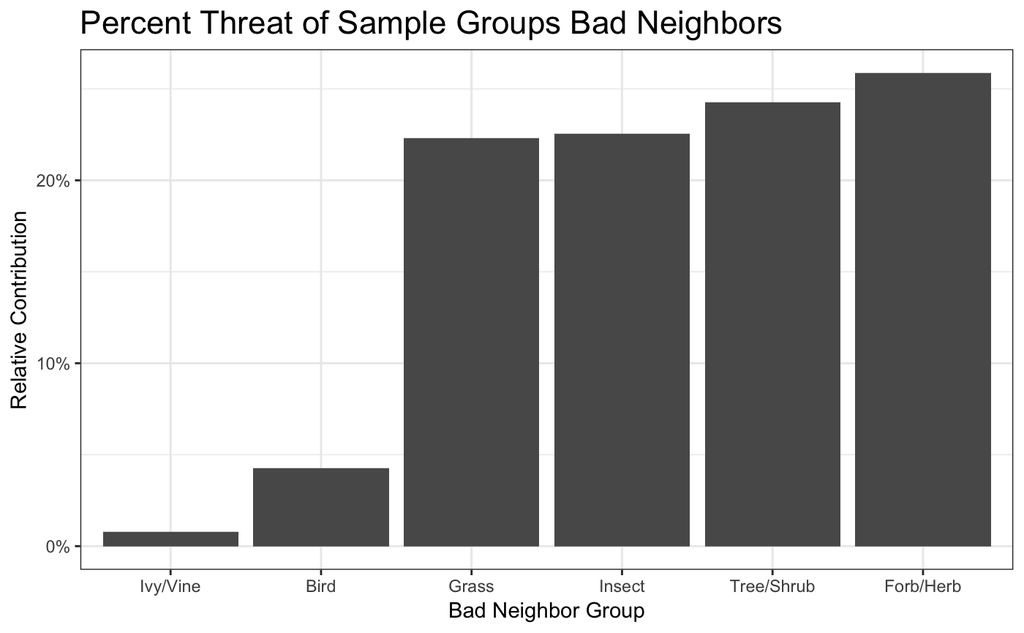

The results indicate the Forb/Herb group present the greatest overall threat, with Tree/Shrub, Insects, and Grass close behind. Recall, a Bad Neighbor is defined as a species that is not yet documented in a given state. Therefore, these results suggest many states are not yet invaded. Birds are a smaller Bad Neighbor, possibly because of migration and ease of movement. The low (almost zero) results for Ivy/Vines suggest the species in this group *already* occur in the states, or the taxon itself is under-represented in BISON.

## Maps

Maps can help describe the problem and where it is occurring. A chloropleth map describes the location of the states under greatest threat. The results of the Bad Neighbor Analysis contain the number of species in adjacent states that are not currently documented in the state of interest. Therefore, plotting this count as a color intensity describes those states that are under most threat. The first map is for all groups combined.

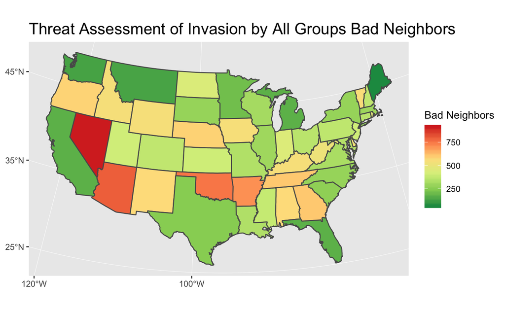

The summary map shows all states have Bad Neighbors from some group. The areas of red in the map indicate those states under the greatest threat from its neighbors; that is, there are an increasing number of non-native species in neighboring states that are not yet documented in the state itself. The package provides a list of the actual bad neighbor species a land manager in the state might use to prioritize monitoring.

States that are colored green present a more nuanced result. Most simply, a lower number of bad neighbors can indicate a lack of non-native species. However, a more realistic interpretation is the state is already host to most of the non-native species present in adjacent states. Florida, for example, is dark green and only has 171 Bad Neighbors, but is known to already be host to many non-native species. Several states in green also lack neighbors (Canada is not used in this analysis). Maine, for example, has only a single neighbor, which limits both the analysis and the interpretation.

### Taxon Group Results

The result maps from each individual taxon group are presented below in descending order.

**Forb/Herb**

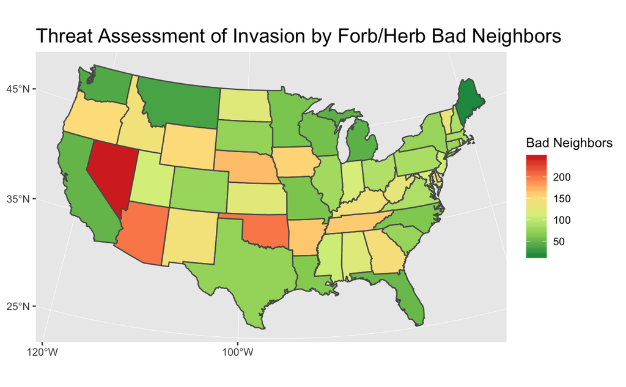

The map for the Forb/Herb taxon groups visually indicates all states have some level of bad neighbors; the mid-greens seen across the map have over 50 bad neighbors extending to over 200 in the red states. The presence of yellow and red show states have not yet observed the invading species. The highest level of bad neighbors is seen in the southwest U.S.

**Tree/Shrub**

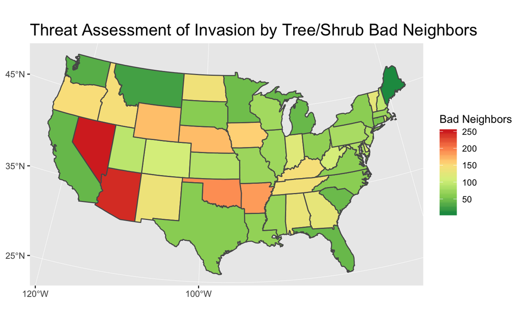

The distribution for the Tree/Shrub taxon groups is similar to that of the Forb/Herb groups. The levels of bad neighbors in mid-green, with 50-100 neighbors in this case, are higher for this group. Like the Forb/Herb group, the highest level of bad neighbors is in the southwest U.S., which might suggest an ecosystem component limiting movement of these plant groups.

**Insect**

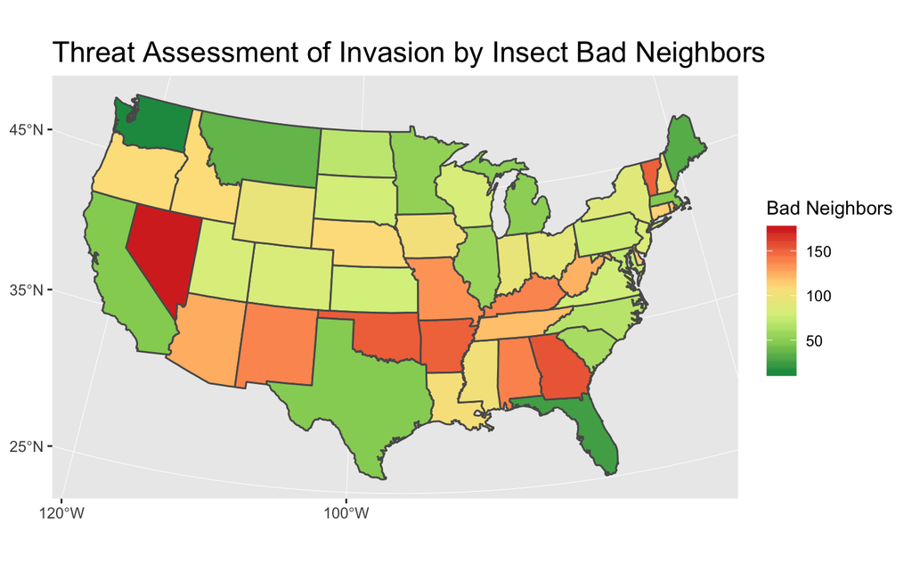

The map of the Insect taxon group visually indicates more red, or more states that have not yet been invaded, but are under threat. Much of the red is across the southern half of the country. There is a notable red state in the northeast (Vermont). However, the overall numeric range of bad neighbors is lower than that of the Forb/Herb and Tree/Shrub groups.

**Grass**

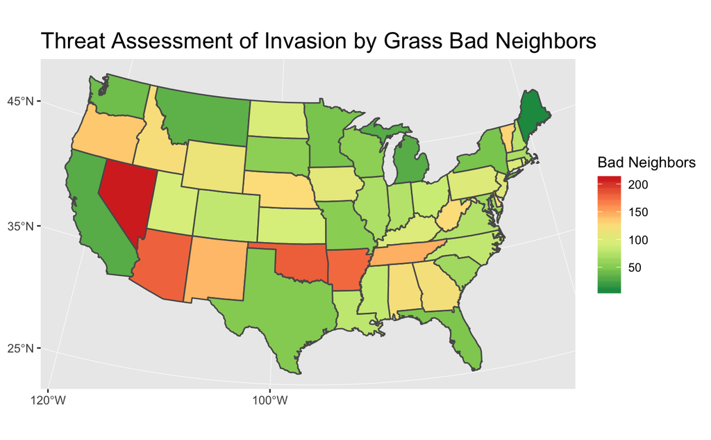

Visually, the distribution of bad neighbors for the Grasses taxon groups is similar to both the Forb/Herb and Tree/Shrub groups, as is the numeric range. There is again an increase in bad neighbors in the southwest.

**Birds**

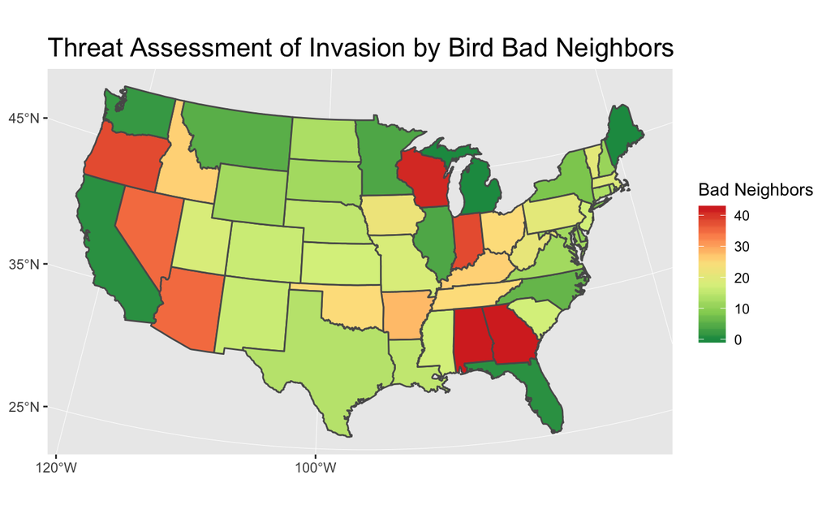

Birds are highly mobile, but these results suggest mobility is limited by some other factors in various parts of the county. Those states in green, indicate a low level of bad neighbors, which can be interpreted as already invaded. The central U.S. seems to have a steady level of mid-green, which suggests birds move freely between these ecosystems. The red colors indicate an increasing level of bad neighbors. The west U.S. has several states in red, which can be explained on a high level through the presence of mountains limiting mobility/opportunity. However, the red in the southeast is not as easily explained and requires further study.

**Ivy/Vine**

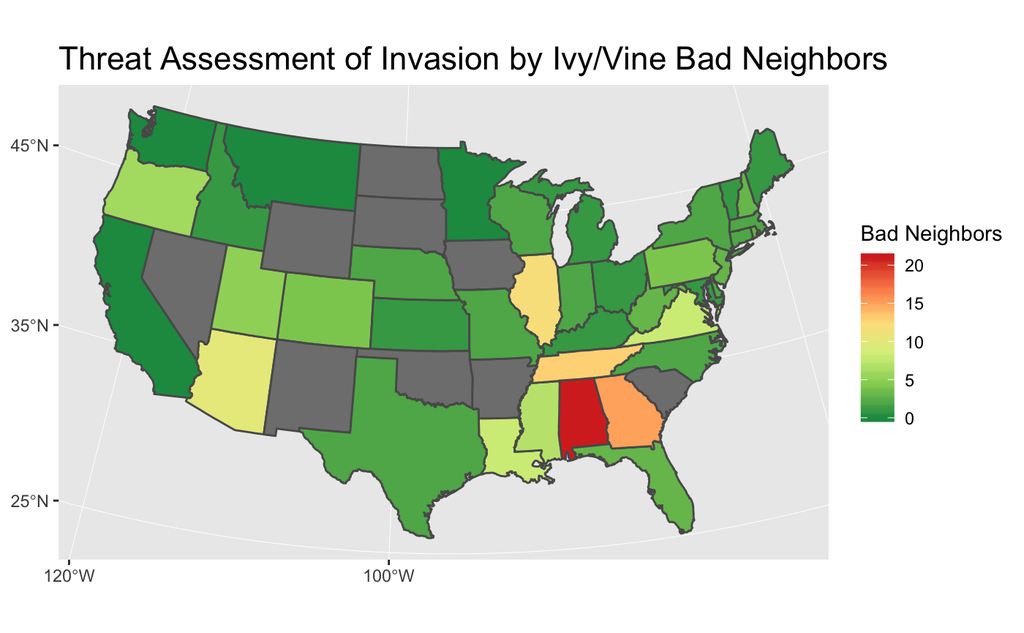

The map for Ivy/Vine bad neighbors indicates there is a lack of data for this taxon, seen as states in gray. The earlier interpretation of the ivy/vine taxon groups as being under-represented in BISON seems to be the case. Further interpretation of these results is obscured, since data gaps preclude the full generation of whether a bad neighbor is actually present.

### Demonstration of state-level results

The following is an illustration of how specific taxon group results might be presented to a user when a particular state is selected. The user would “click”, or select, a state of interest, and be presented with a summary of the results and list of Bad Neighbor species in the taxon group.

The `generate_state_report.R` function was written to produce the text:

```r
source("R/generate_state_report_text.R")
# print a text report
cat(generate_state_report_text("Colorado", group_name = "Insect", comb_all_results_insects))
```

```
Bad Neighbors pose a threat of 84 species of Insect that are invasive to Colorado, but are not yet documented within the state.

There are currently 68 species of invasive Insect with a documented presence in the state.  Invasive species within Colorado may pose a threat to surrounding states.

Click on a name to open a tab with the species full distribution in <a href='https://bison.usgs.gov' target='_blank'>BISON</a>
```

The species list is stored as json in the `results_json` directory. The data were generated on a taxon group-by-group basis, then by state. The separate taxon group json files (e.g. tree/shrub, ivy/vines, forb/herb, grasses) need to be combined into a single list for plant groups. The insect group will be used for illustration since this is only a single taxon group.

The final result can combine the list of scientific names with a link to BISON for more information.

```r
# load the insect result file.  This includes all summaries and species list
species_list <- jsonlite::fromJSON("result_json/insect/Insecta/Colorado_Insecta_bad_neighbor.json")
# parse the result to generate a table of species
species_list$species_list %>%
    select(name, tsn) %>%
    # create an html link from the result
    mutate(link = str_c("<a href ='https://bison.usgs.gov/index.jsp?scientificName=",
                        name,
                        "&ITIS=itis' target='_blank'>")) %>%
    rename("ScientificName" = name, "TSN" = tsn) #rename for clarity
```

| ScientificName | TSN | link |
| --- | --- | --- |
| Acyrthosiphon kondoi | 200571 |  |
| Acyrthosiphon pisum | 200572 |  |
| Aedes aegypti | 126240 |  |
| Aethina tumida | 835800 |  |
| Agonoscelis puberula | 721895 |  |
| Agrilus cyanescens | 809419 |  |
| Agrilus planipennis | 809502 |  |
| Ahasverus advena | 114305 |  |
| Amphipyra tragopoginis | 188955 |  |
| Andrena wilkella | 154363 |  |

[output cut: 74 more lines]

# References

Simpson, A., and M.C. Eyler. 2018. “First Comprehensive List of Non-Native Species Established in the United States, Segregated by Major Regions: U.S. Geological Survey Open-File Report.” *Open File Report* In Press. USGS. https://doi.org/https://doi.org/10.3133/ofr2018.